# Biostat 203B Homework 3

Due Feb 23 @ 11:59PM

Author

Yue Wang UID:005704481

Load necessary libraries (you can add more as needed).

```r
library(arrow)
library(gtsummary)
library(memuse)
library(pryr)
library(R.utils)
library(tidyverse)
library(data.table)
```

Display your machine memory.

```r
memuse::Sys.meminfo()
```

[output not shown]

In this exercise, we use tidyverse (ggplot2, dplyr, etc) to explore the [MIMIC-IV](https://mimic.mit.edu/docs/iv/) data introduced in [homework 1](https://ucla-biostat-203b.github.io/2024winter/hw/hw1/hw1.html) and to build a cohort of ICU stays.

## Q1. Visualizing patient trajectory

Visualizing a patient’s encounters in a health care system is a common task in clinical data analysis. In this question, we will visualize a patient’s ADT (admission-discharge-transfer) history and ICU vitals in the MIMIC-IV data.

### Q1.1 ADT history

A patient’s ADT history records the time of admission, discharge, and transfer in the hospital. This figure shows the ADT history of the patient with `subject_id` 10001217 in the MIMIC-IV data. The x-axis is the calendar time, and the y-axis is the type of event (ADT, lab, procedure). The color of the line segment represents the care unit. The size of the line segment represents whether the care unit is an ICU/CCU. The crosses represent lab events, and the shape of the dots represents the type of procedure. The title of the figure shows the patient’s demographic information and the subtitle shows top 3 diagnoses.

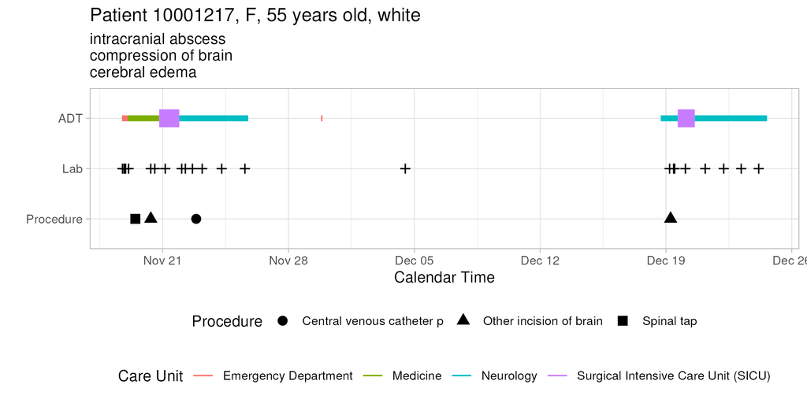

Do a similar visualization for the patient with `subject_id` 10013310 using ggplot.

Hint: We need to pull information from data files `patients.csv.gz`, `admissions.csv.gz`, `transfers.csv.gz`, `labevents.csv.gz`, `procedures_icd.csv.gz`, `diagnoses_icd.csv.gz`, `d_icd_procedures.csv.gz`, and `d_icd_diagnoses.csv.gz`. For the big file `labevents.csv.gz`, use the Parquet format you generated in Homework 2. For reproducibility, make the Parquet folder `labevents_pq` available at the current working directory `hw3`, for example, by a symbolic link. Make your code reproducible.

**Answer:** Prepare the data.

```bash
## ln -s ~/203b-lecture/203b-hw/hw2/labevents.parquet
##  ~/203b-lecture/203b-hw/hw3/labevents.parquet
```

```r
patients <- read_csv("~/mimic/hosp/patients.csv.gz", lazy = TRUE)
admissions <- read_csv("~/mimic/hosp/admissions.csv.gz", lazy = TRUE)
transfers <- read_csv("~/mimic/hosp/transfers.csv.gz", lazy = TRUE)
pro_icd <- read_csv("~/mimic/hosp/procedures_icd.csv.gz", lazy = TRUE)
diag_icd <- read_csv("~/mimic/hosp/diagnoses_icd.csv.gz", lazy = TRUE)
d_icd_pro <- read_csv("~/mimic/hosp/d_icd_procedures.csv.gz", lazy = TRUE)
d_icd_diag <- read_csv("~/mimic/hosp/d_icd_diagnoses.csv.gz", lazy = TRUE)
patient_1 <- patients %>% filter(subject_id == 10013310)
admissions_1 <- admissions %>% filter(subject_id == 10013310)
transfers_1 <- transfers %>% filter(subject_id == 10013310)
pro_icd_1 <- pro_icd %>% filter(subject_id == 10013310)
diag_icd_1 <- diag_icd %>% filter(subject_id == 10013310)
#
```

```r
labevents_1 <- arrow::open_dataset("labevents.parquet") %>%
  select(subject_id, charttime) %>%
  filter(subject_id == 10013310) %>%
  collect()
```

**Answer:** `patient_1` and `admissions_1` include the info we need for the title, thus we can can tell the title would be “Patient 10013310, F, 70 years old, black/african”

```r
print(patient_1, width = Inf)
print(admissions_1, width = Inf)
```

[output not shown]

**Answer:** Subtitles need to include top 3 diagnosis. I will take the first three diagnosis for the first hospital admission. From the `admission_1` table, we found that the `hadm_id` for the first admission is 27682188. I will then filter for the first three diagnoses based on `seq_num`.

```r
hadm_id_top3 <- diag_icd_1 %>%
  filter(hadm_id == 27682188) %>%
  arrange(seq_num) %>%
  head(3)

top3_diag <- hadm_id_top3 %>%
  left_join(d_icd_diag, by = c("icd_code", "icd_version"))

top3_diag_names <- top3_diag$long_title
print(top3_diag_names)
```

```
[1] "ST elevation (STEMI) myocardial infarction involving right coronary artery"
[2] "Acute kidney failure with tubular necrosis"
[3] "Acute on chronic systolic (congestive) heart failure"
```

```r
# prepare the procedure data
pro_full <- pro_icd_1 %>%
  left_join(d_icd_pro, by = c("icd_code", "icd_version"))
pro_full <- pro_full %>%
  mutate(short_title = case_when(
    icd_code == "   4A023N7" ~ "Left Heart Cardiac Sampling and Pressure",
    icd_code == "B2111ZZ" ~ "Coronary Arteries Fluoroscopy",
    icd_code == "B241ZZ3" ~ "oronary Arteries Ultrasonography",
    icd_code == "03CG3ZZ" ~ "Intracranial Artery Matter Extirpation",
    icd_code == "3E05317" ~ "Peripheral Artery Thrombolytic Introduction",
    icd_code == "0DH63UZ" ~ "Gastric Feeding Device Insertion",
    icd_code == "3E0G76Z" ~ "Upper GI Nutritional Substance Introduction",
    icd_code == "027034Z" ~ "Coronary Artery Dilation with Device",
    icd_code == "B211YZZ" ~ "Fluoroscopy with Other Coronary Contrast"))
print(pro_full, width = Inf)
```

```
# A tibble: 9 × 8
  subject_id  hadm_id seq_num chartdate  icd_code icd_version
       <dbl>    <dbl>   <dbl> <date>     <chr>          <dbl>
1   10013310 21243435       1 2153-05-27 4A023N7           10
2   10013310 21243435       2 2153-05-27 B2111ZZ           10
3   10013310 21243435       3 2153-05-27 B241ZZ3           10
4   10013310 22098926       1 2153-06-10 03CG3ZZ           10
5   10013310 22098926       2 2153-06-10 3E05317           10
6   10013310 22098926       3 2153-07-15 0DH63UZ           10
7   10013310 22098926       4 2153-06-11 3E0G76Z           10
8   10013310 27682188       1 2153-05-06 027034Z           10
9   10013310 27682188       2 2153-05-06 B211YZZ           10
  long_title
  <chr>
1 Measurement of Cardiac Sampling and Pressure, Left Heart, Percutaneous Approa…
```

[output cut: 19 more lines]

```r
transfers_1 <- transfers_1 %>%
  mutate(careunit_1 = case_when(
    careunit == "Emergency Department" ~ "Emergency Department",
    careunit == "Medicine/Cardiology" ~ "Medicine",
    careunit == "Neuro Intermediate" ~ "Neuro Intermediate",
    careunit == "Neuro Surgical Intensive Care Unit (Neuro SICU)" ~ "ICU",
    careunit == "Medicine" ~ "Medicine",
    careunit == "Coronary Care Unit (CCU)" ~ "ICU"))
transfers_1$is_icu <- grepl("CU", transfers_1$careunit_1)
#
transfers_plot <- transfers_1 %>%
  mutate(event_category = 'ADT')
labevents_plot <- labevents_1 %>%
  mutate(event_category = 'Lab')
procedures_plot <- pro_full %>%
  mutate(event_category = 'Procedure')
#
combined_data <- bind_rows(transfers_plot, labevents_plot, procedures_plot)
combined_data$chartdate <- as.POSIXct(combined_data$chartdate,
  format = "%Y-%m-%d %H:%M:%S")
#
final_plot <-
ggplot(combined_data) +
  geom_segment(data = subset(combined_data, event_category == 'ADT'),
               aes(x = intime, xend = outtime, y = event_category,
               yend = event_category, color = careunit_1, linewidth = is_icu)) +
  geom_point(data = subset(combined_data, event_category == 'Lab'),
             aes(x = charttime, y = event_category), shape = 3) +
  geom_point(data = subset(combined_data, event_category == 'Procedure'),
             aes(x = chartdate, y = event_category, shape = short_title)) +
  scale_color_manual(values = c("Emergency Department" = "red",
                              "Medicine" = "green", "Neuro Intermediate" =
                                "blue", "ICU" = "purple")) +
  scale_size_manual(values = c(1, 5)) +
  labs(title = "Patient 10013310, F, 70 years old, black/african",
       subtitle = "STEMI involving right coronary artery
       acute kidney failure with tubular necrosis
       acute on chronic systolic (congestive) heart failure",
       x = "Calendar Time", y = "") +
  theme_minimal() +
  theme_light() +
  theme(axis.text.x = element_text(angle = 45, vjust = 1, hjust=1, size = 8),
        axis.text.y = element_text(size = 7),
        legend.position = "right")
ggsave("10013310.png", plot = final_plot, width = 20, height = 10, dpi = 300)
```

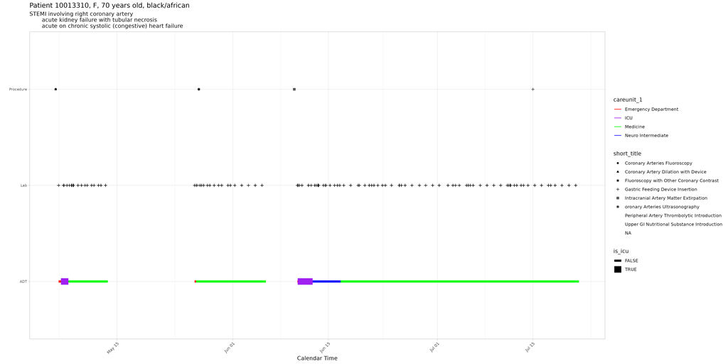

### Q1.2 ICU stays

ICU stays are a subset of ADT history. This figure shows the vitals of the patient `10001217` during ICU stays. The x-axis is the calendar time, and the y-axis is the value of the vital. The color of the line represents the type of vital. The facet grid shows the abbreviation of the vital and the stay ID.

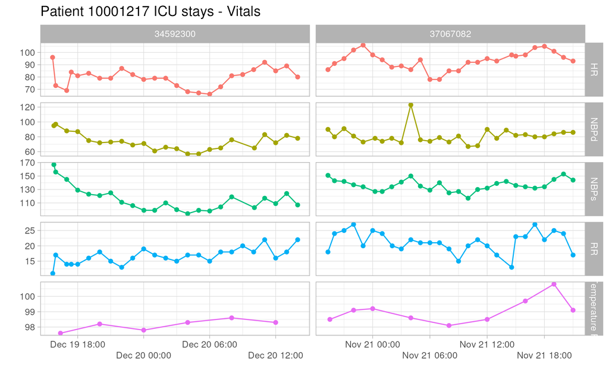

Do a similar visualization for the patient `10013310`.

**Answer:** First, we need the data in the vitals for ICU patients, which is the exercise we did in hw2. Because in hw2, we only have the `itemid` for mean non-invasive blood pressure (220181), so I will use NBPm instead of NBPd.

```bash
cd  ~/mimic/icu
gzip -cd chartevents.csv.gz > ~/203b-lecture/203b-hw/hw3/chartevents.csv
```

```r
item_ids_chart <- c(220045, 220181, 220179, 223761, 220210)
icu_vital_1.2 <- open_dataset("chartevents.csv", format = "csv") %>%
  select(subject_id, hadm_id, itemid, charttime, valuenum) %>%
  filter(itemid %in% item_ids_chart, subject_id == 10013310) %>%
  collect()
```

```r
item_names <- data.frame(
  itemid = c(220045, 220181, 220179, 223761, 220210),
  item_name = c("HR", "NBPm", "NBPs", "Temperature", "RR"))

icu_vital_1.2 <- icu_vital_1.2 %>%
  left_join(item_names, by = "itemid")
```

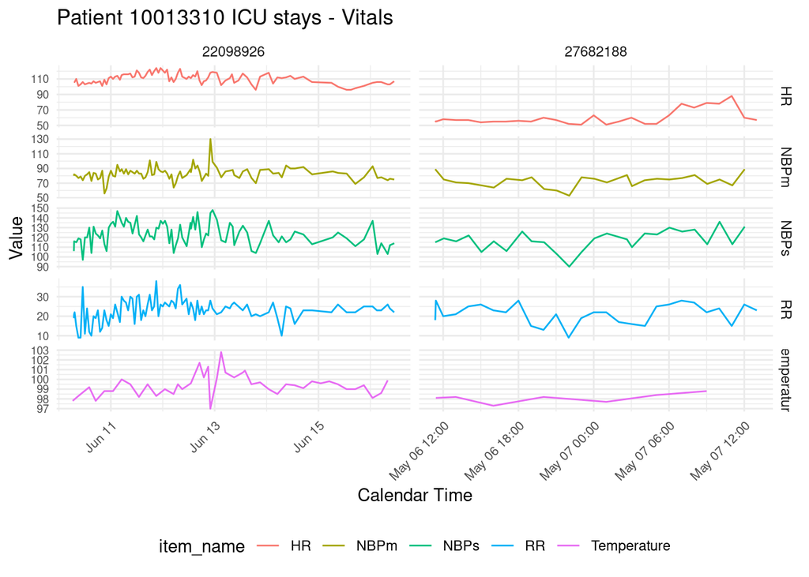

```r
ggplot(data = icu_vital_1.2, aes(x = charttime, y = valuenum, group = hadm_id,
  color = item_name)) +
  geom_line() +
  facet_grid(item_name ~ hadm_id, scales = "free", space = "fixed") +
  theme_minimal() +
  labs(title = "Patient 10013310 ICU stays - Vitals",
  x = "Calendar Time",
  y = "Value") +
  theme_minimal() +
  theme(axis.text.x = element_text(angle = 45, vjust = 1, hjust=1, size = 8),
  axis.text.y = element_text(size = 7),
  legend.position = "bottom")
```

## Q2. ICU stays

`icustays.csv.gz` (https://mimic.mit.edu/docs/iv/modules/icu/icustays/) contains data about Intensive Care Units (ICU) stays. The first 10 lines are

```bash
zcat < ~/mimic/icu/icustays.csv.gz | head
```

```
subject_id,hadm_id,stay_id,first_careunit,last_careunit,intime,outtime,los
10000032,29079034,39553978,Medical Intensive Care Unit (MICU),Medical Intensive Care Unit (MICU),2180-07-23 14:00:00,2180-07-23 23:50:47,0.4102662037037037
10000980,26913865,39765666,Medical Intensive Care Unit (MICU),Medical Intensive Care Unit (MICU),2189-06-27 08:42:00,2189-06-27 20:38:27,0.4975347222222222
10001217,24597018,37067082,Surgical Intensive Care Unit (SICU),Surgical Intensive Care Unit (SICU),2157-11-20 19:18:02,2157-11-21 22:08:00,1.1180324074074075
10001217,27703517,34592300,Surgical Intensive Care Unit (SICU),Surgical Intensive Care Unit (SICU),2157-12-19 15:42:24,2157-12-20 14:27:41,0.9481134259259258
10001725,25563031,31205490,Medical/Surgical Intensive Care Unit (MICU/SICU),Medical/Surgical Intensive Care Unit (MICU/SICU),2110-04-11 15:52:22,2110-04-12 23:59:56,1.338587962962963
10001884,26184834,37510196,Medical Intensive Care Unit (MICU),Medical Intensive Care Unit (MICU),2131-01-11 04:20:05,2131-01-20 08:27:30,9.171817129629629
10002013,23581541,39060235,Cardiac Vascular Intensive Care Unit (CVICU),Cardiac Vascular Intensive Care Unit (CVICU),2160-05-18 10:00:53,2160-05-19 17:33:33,1.3143518518518518
10002155,20345487,32358465,Medical Intensive Care Unit (MICU),Medical Intensive Care Unit (MICU),2131-03-09 21:33:00,2131-03-10 18:09:21,0.8585763888888889
10002155,23822395,33685454,Coronary Care Unit (CCU),Coronary Care Unit (CCU),2129-08-04 12:45:00,2129-08-10 17:02:38,6.178912037037037
```

### Q2.1 Ingestion

Import `icustays.csv.gz` as a tibble `icustays_tble`.

```r
icustays_tble <- read_csv("~/mimic/icu/icustays.csv.gz")
```

### Q2.2 Summary and visualization

How many unique `subject_id`? Can a `subject_id` have multiple ICU stays? Summarize the number of ICU stays per `subject_id` by graphs.

**Answer:** By running the code, we can tell that we have 50,920 unique `subject_id`, thus we do have some `subject_id` have multiple ICU stays since the original row number is 73,181.

```r
unique_subject_id <- icustays_tble %>% distinct(subject_id)
nrow(unique_subject_id)
```

```
[1] 50920
```

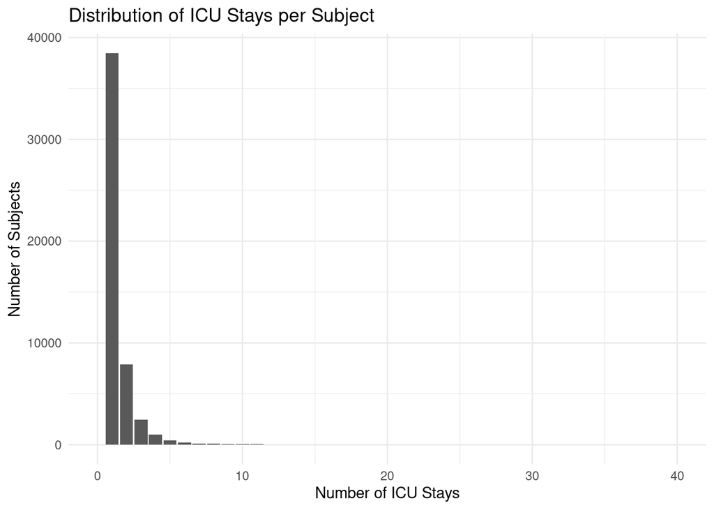

```r
icu_summary <- icustays_tble %>%
  group_by(subject_id) %>%
  summarise(icu_stays_num = n()) %>%
  count(icu_stays_num)

ggplot(icu_summary, aes(x = icu_stays_num, y = n)) +
  geom_bar(stat = "identity") +
  theme_minimal() +
  labs(x = "Number of ICU Stays", y = "Number of Subjects",
       title = "Distribution of ICU Stays per Subject") +
  xlim(0, 40)
```

## Q3. `admissions` data

Information of the patients admitted into hospital is available in `admissions.csv.gz`. See https://mimic.mit.edu/docs/iv/modules/hosp/admissions/ for details of each field in this file. The first 10 lines are

```bash
zcat < ~/mimic/hosp/admissions.csv.gz | head
```

```
subject_id,hadm_id,admittime,dischtime,deathtime,admission_type,admit_provider_id,admission_location,discharge_location,insurance,language,marital_status,race,edregtime,edouttime,hospital_expire_flag
10000032,22595853,2180-05-06 22:23:00,2180-05-07 17:15:00,,URGENT,P874LG,TRANSFER FROM HOSPITAL,HOME,Other,ENGLISH,WIDOWED,WHITE,2180-05-06 19:17:00,2180-05-06 23:30:00,0
10000032,22841357,2180-06-26 18:27:00,2180-06-27 18:49:00,,EW EMER.,P09Q6Y,EMERGENCY ROOM,HOME,Medicaid,ENGLISH,WIDOWED,WHITE,2180-06-26 15:54:00,2180-06-26 21:31:00,0
10000032,25742920,2180-08-05 23:44:00,2180-08-07 17:50:00,,EW EMER.,P60CC5,EMERGENCY ROOM,HOSPICE,Medicaid,ENGLISH,WIDOWED,WHITE,2180-08-05 20:58:00,2180-08-06 01:44:00,0
10000032,29079034,2180-07-23 12:35:00,2180-07-25 17:55:00,,EW EMER.,P30KEH,EMERGENCY ROOM,HOME,Medicaid,ENGLISH,WIDOWED,WHITE,2180-07-23 05:54:00,2180-07-23 14:00:00,0
10000068,25022803,2160-03-03 23:16:00,2160-03-04 06:26:00,,EU OBSERVATION,P51VDL,EMERGENCY ROOM,,Other,ENGLISH,SINGLE,WHITE,2160-03-03 21:55:00,2160-03-04 06:26:00,0
10000084,23052089,2160-11-21 01:56:00,2160-11-25 14:52:00,,EW EMER.,P6957U,WALK-IN/SELF REFERRAL,HOME HEALTH CARE,Medicare,ENGLISH,MARRIED,WHITE,2160-11-20 20:36:00,2160-11-21 03:20:00,0
10000084,29888819,2160-12-28 05:11:00,2160-12-28 16:07:00,,EU OBSERVATION,P63AD6,PHYSICIAN REFERRAL,,Medicare,ENGLISH,MARRIED,WHITE,2160-12-27 18:32:00,2160-12-28 16:07:00,0
10000108,27250926,2163-09-27 23:17:00,2163-09-28 09:04:00,,EU OBSERVATION,P38XXV,EMERGENCY ROOM,,Other,ENGLISH,SINGLE,WHITE,2163-09-27 16:18:00,2163-09-28 09:04:00,0
10000117,22927623,2181-11-15 02:05:00,2181-11-15 14:52:00,,EU OBSERVATION,P2358X,EMERGENCY ROOM,,Other,ENGLISH,DIVORCED,WHITE,2181-11-14 21:51:00,2181-11-15 09:57:00,0
```

### Q3.1 Ingestion

Import `admissions.csv.gz` as a tibble `admissions_tble`. **Answer:** The `admission.csv.gz` has already be imported as a tibble in Q1, I will just make a copy of it and name it `admissions_tble`

```r
admissions_tble <- admissions
print(admissions_tble, width = Inf)
```

```
# A tibble: 431,231 × 16
   subject_id  hadm_id admittime           dischtime           deathtime
        <dbl>    <dbl> <dttm>              <dttm>              <dttm>
 1   10000032 22595853 2180-05-06 22:23:00 2180-05-07 17:15:00 NA
 2   10000032 22841357 2180-06-26 18:27:00 2180-06-27 18:49:00 NA
 3   10000032 25742920 2180-08-05 23:44:00 2180-08-07 17:50:00 NA
 4   10000032 29079034 2180-07-23 12:35:00 2180-07-25 17:55:00 NA
 5   10000068 25022803 2160-03-03 23:16:00 2160-03-04 06:26:00 NA
 6   10000084 23052089 2160-11-21 01:56:00 2160-11-25 14:52:00 NA
 7   10000084 29888819 2160-12-28 05:11:00 2160-12-28 16:07:00 NA
 8   10000108 27250926 2163-09-27 23:17:00 2163-09-28 09:04:00 NA
 9   10000117 22927623 2181-11-15 02:05:00 2181-11-15 14:52:00 NA
10   10000117 27988844 2183-09-18 18:10:00 2183-09-21 16:30:00 NA
   admission_type    admit_provider_id admission_location     discharge_location
   <chr>             <chr>             <chr>                  <chr>
```

[output cut: 35 more lines]

### Q3.2 Summary and visualization

Summarize the following information by graphics and explain any patterns you see.

- number of admissions per patient **Answer:** We can tell that it’s a extremely skewed data.

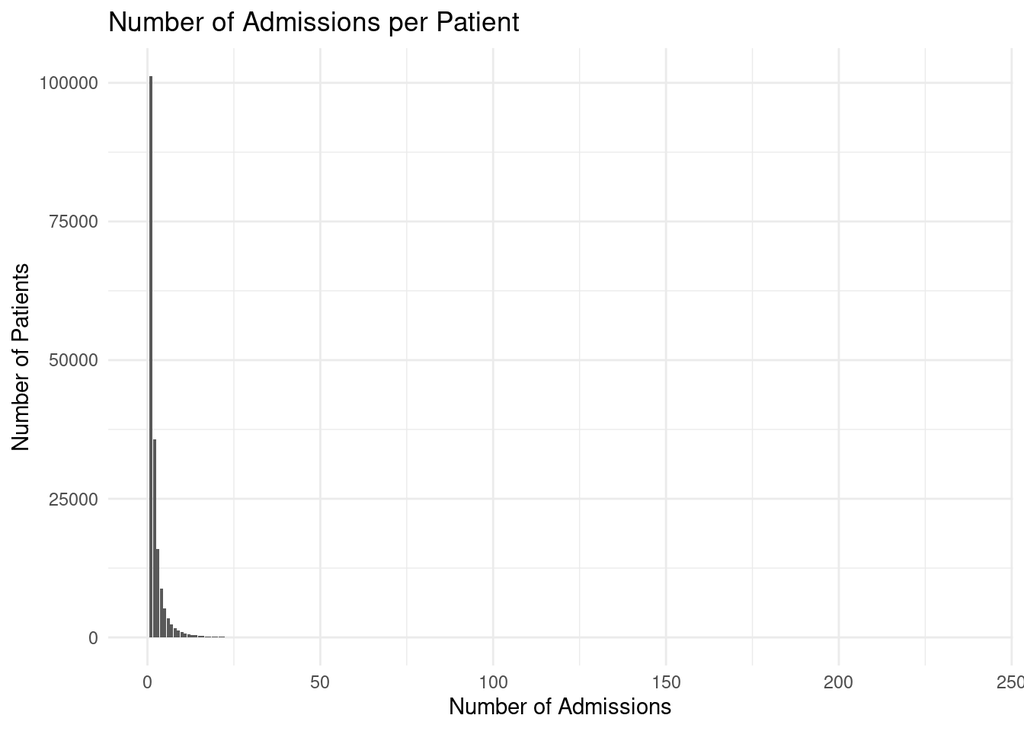

```r
admissions_per_patient <- admissions_tble %>%
  group_by(subject_id) %>%
  summarise(number_of_admissions = n()) %>%
  count(number_of_admissions)

ggplot(data = admissions_per_patient) +
  geom_col(mapping = aes(x = number_of_admissions, y = n))+
  theme_minimal() +
  labs(title = "Number of Admissions per Patient",
       x = "Number of Admissions",
       y = "Number of Patients")
```

- admission hour (anything unusual?)

```r
class(admissions_tble$admittime)
```

```
[1] "POSIXct" "POSIXt"
```

**Answer:** The hospital have a lot of admissions at 0 AM and 7 AM compared to other time slots. It’s kind of unusual to me, but not sure why is this happening.

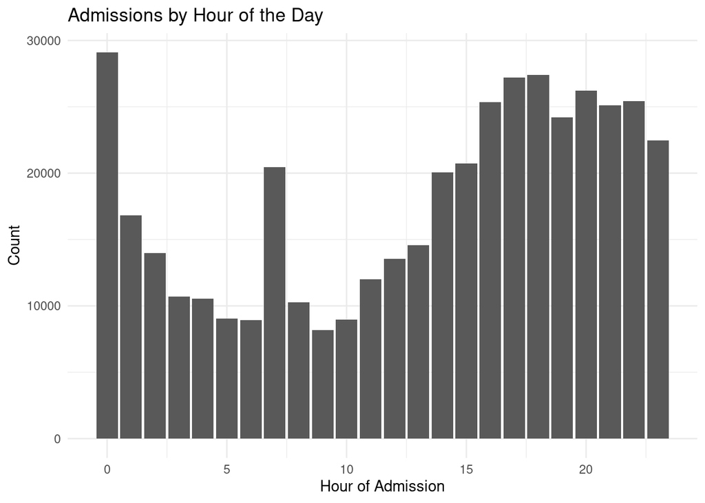

```r
admissions_tble <- admissions_tble %>%
  mutate("admit_hour" = hour((admittime)))

ggplot(admissions_tble) +
  geom_bar(mapping = aes (x = admit_hour)) +
  theme_minimal() +
  labs(title = "Admissions by Hour of the Day",
       x = "Hour of Admission",
       y = "Count")
```

- admission minute (anything unusual?)

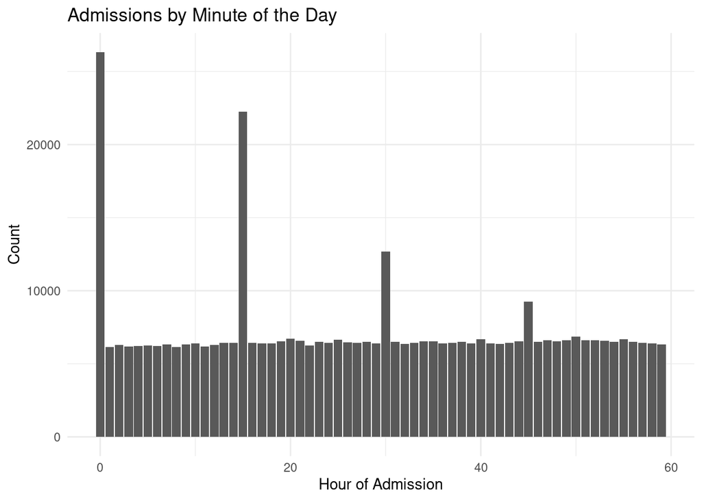

```r
admissions_tble <- admissions_tble %>%
  mutate("admit_min" = minute((admittime)))

ggplot(admissions_tble) +
  geom_bar(mapping = aes (x = admit_min)) +
  theme_minimal() +
  labs(title = "Admissions by Minute of the Day",
       x = "Hour of Admission",
       y = "Count")
```

**Answer:** The plot showed high frequency at 0, 15, 30 and 45 minutes， possibly due to the rounding.

- length of hospital stay (from admission to discharge) (anything unusual?)

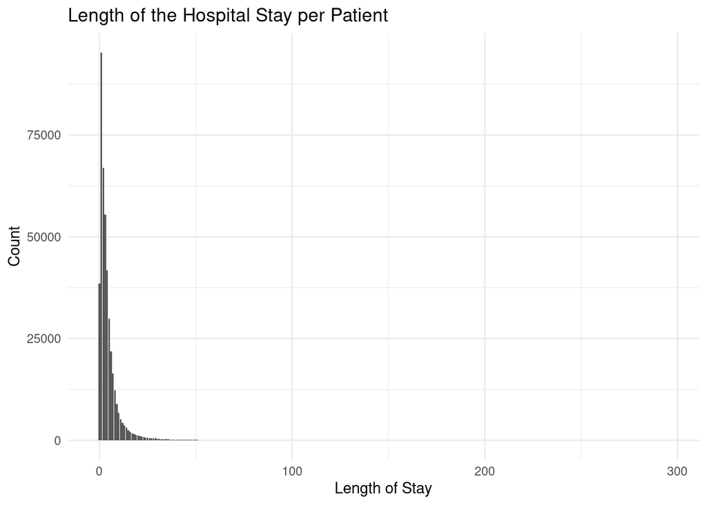

```r
admissions_tble <- admissions_tble %>%
  mutate("length_stay" = round(as.numeric(difftime(admissions_tble$dischtime,
                                  admissions_tble$admittime,
                                  units = "days"))))


ggplot(admissions_tble) +
  geom_bar(mapping = aes (x = length_stay)) +
  theme_minimal() +
  labs(title = "Length of the Hospital Stay per Patient",
       x = "Length of Stay",
       y = "Count")
```

**Answer:** We have a lot of people with length of stay equals to 0 and -1, which is quite unusual, not sure what was happening.

According to the [MIMIC-IV documentation](https://mimic.mit.edu/docs/iv/about/concepts/#date-shifting),

> All dates in the database have been shifted to protect patient confidentiality. Dates will be internally consistent for the same patient, but randomly distributed in the future. Dates of birth which occur in the present time are not true dates of birth. Furthermore, dates of birth which occur before the year 1900 occur if the patient is older than 89. In these cases, the patient’s age at their first admission has been fixed to 300.

## Q4. `patients` data

Patient information is available in `patients.csv.gz`. See https://mimic.mit.edu/docs/iv/modules/hosp/patients/ for details of each field in this file. The first 10 lines are

```bash
zcat < ~/mimic/hosp/patients.csv.gz | head
```

```
subject_id,gender,anchor_age,anchor_year,anchor_year_group,dod
10000032,F,52,2180,2014 - 2016,2180-09-09
10000048,F,23,2126,2008 - 2010,
10000068,F,19,2160,2008 - 2010,
10000084,M,72,2160,2017 - 2019,2161-02-13
10000102,F,27,2136,2008 - 2010,
10000108,M,25,2163,2014 - 2016,
10000115,M,24,2154,2017 - 2019,
10000117,F,48,2174,2008 - 2010,
10000178,F,59,2157,2017 - 2019,
```

### Q4.1 Ingestion

Import `patients.csv.gz` (https://mimic.mit.edu/docs/iv/modules/hosp/patients/) as a tibble `patients_tble`. **Answer:** The `patients.csv.gz` has already be imported as a tibble in Q1, I will just make a copy of it and name it `patients_tble`

```r
patients_tble <- patients
print(patients_tble, width = Inf)
```

```
# A tibble: 299,712 × 6
   subject_id gender anchor_age anchor_year anchor_year_group dod
        <dbl> <chr>       <dbl>       <dbl> <chr>             <date>
 1   10000032 F              52        2180 2014 - 2016       2180-09-09
 2   10000048 F              23        2126 2008 - 2010       NA
 3   10000068 F              19        2160 2008 - 2010       NA
 4   10000084 M              72        2160 2017 - 2019       2161-02-13
 5   10000102 F              27        2136 2008 - 2010       NA
 6   10000108 M              25        2163 2014 - 2016       NA
 7   10000115 M              24        2154 2017 - 2019       NA
 8   10000117 F              48        2174 2008 - 2010       NA
 9   10000178 F              59        2157 2017 - 2019       NA
10   10000248 M              34        2192 2014 - 2016       NA
# ℹ 299,702 more rows
```

### Q4.2 Summary and visualization

Summarize variables `gender` and `anchor_age` by graphics, and explain any patterns you see.

**Answer:** The first graph is the histogram showing the distribution of gender, more females presented. The second boxplot showed the anchor distribution by gender. Both have a similar range, whereas males have a higher median anchor age compared to females.

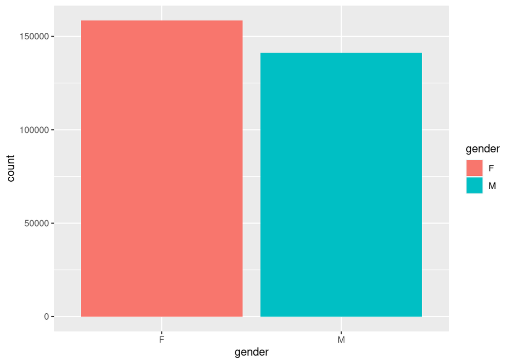

```r
ggplot(patients_tble) +
  geom_bar(aes(x = gender, fill = gender))
```

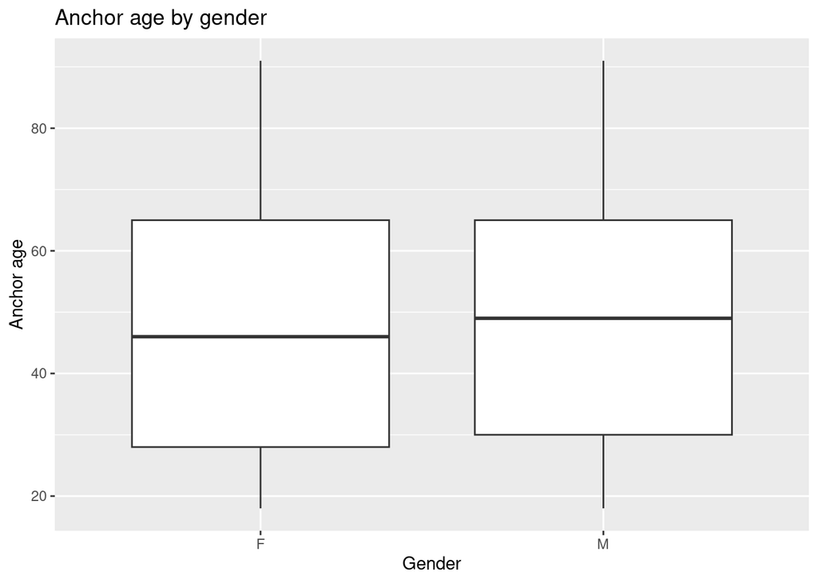

```r
ggplot(data = patients_tble, mapping = aes(x = gender,
                                           y = anchor_age)) +
  geom_boxplot() + labs(title = "Anchor age by gender") +
  labs(x = "Gender", y = "Anchor age")
```

**Answer:** This graph also showed the anchor_age distribution by gender. We have a peak at age 91. Both gender have a similar trend.

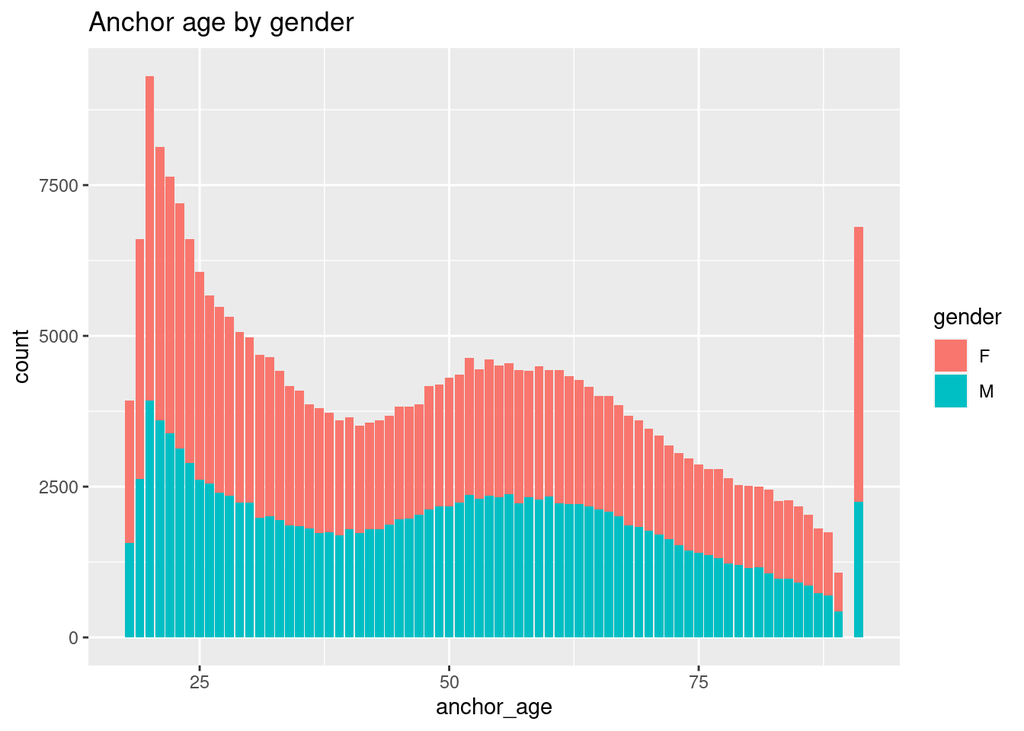

```r
ggplot(patients_tble) +
  geom_bar(aes(x = anchor_age, fill = gender)) +
  labs(title = "Anchor age by gender")
```

## Q5. Lab results

`labevents.csv.gz` (https://mimic.mit.edu/docs/iv/modules/hosp/labevents/) contains all laboratory measurements for patients. The first 10 lines are

```bash
zcat < ~/mimic/hosp/labevents.csv.gz | head
```

```
labevent_id,subject_id,hadm_id,specimen_id,itemid,order_provider_id,charttime,storetime,value,valuenum,valueuom,ref_range_lower,ref_range_upper,flag,priority,comments
1,10000032,,45421181,51237,P28Z0X,2180-03-23 11:51:00,2180-03-23 15:15:00,1.4,1.4,,0.9,1.1,abnormal,ROUTINE,
2,10000032,,45421181,51274,P28Z0X,2180-03-23 11:51:00,2180-03-23 15:15:00,___,15.1,sec,9.4,12.5,abnormal,ROUTINE,VERIFIED.
3,10000032,,52958335,50853,P28Z0X,2180-03-23 11:51:00,2180-03-25 11:06:00,___,15,ng/mL,30,60,abnormal,ROUTINE,NEW ASSAY IN USE ___: DETECTS D2 AND D3 25-OH ACCURATELY.
4,10000032,,52958335,50861,P28Z0X,2180-03-23 11:51:00,2180-03-23 16:40:00,102,102,IU/L,0,40,abnormal,ROUTINE,
5,10000032,,52958335,50862,P28Z0X,2180-03-23 11:51:00,2180-03-23 16:40:00,3.3,3.3,g/dL,3.5,5.2,abnormal,ROUTINE,
6,10000032,,52958335,50863,P28Z0X,2180-03-23 11:51:00,2180-03-23 16:40:00,109,109,IU/L,35,105,abnormal,ROUTINE,
7,10000032,,52958335,50864,P28Z0X,2180-03-23 11:51:00,2180-03-23 16:40:00,___,8,ng/mL,0,8.7,,ROUTINE,MEASURED BY ___.
8,10000032,,52958335,50868,P28Z0X,2180-03-23 11:51:00,2180-03-23 16:40:00,12,12,mEq/L,8,20,,ROUTINE,
9,10000032,,52958335,50878,P28Z0X,2180-03-23 11:51:00,2180-03-23 16:40:00,143,143,IU/L,0,40,abnormal,ROUTINE,
```

`d_labitems.csv.gz` (https://mimic.mit.edu/docs/iv/modules/hosp/d_labitems/) is the dictionary of lab measurements.

```bash
zcat < ~/mimic/hosp/d_labitems.csv.gz | head
```

```
itemid,label,fluid,category
50801,Alveolar-arterial Gradient,Blood,Blood Gas
50802,Base Excess,Blood,Blood Gas
50803,"Calculated Bicarbonate, Whole Blood",Blood,Blood Gas
50804,Calculated Total CO2,Blood,Blood Gas
50805,Carboxyhemoglobin,Blood,Blood Gas
50806,"Chloride, Whole Blood",Blood,Blood Gas
50808,Free Calcium,Blood,Blood Gas
50809,Glucose,Blood,Blood Gas
50810,"Hematocrit, Calculated",Blood,Blood Gas
```

We are interested in the lab measurements of creatinine (50912), potassium (50971), sodium (50983), chloride (50902), bicarbonate (50882), hematocrit (51221), white blood cell count (51301), and glucose (50931). Retrieve a subset of `labevents.csv.gz` that only containing these items for the patients in `icustays_tble`. Further restrict to the last available measurement (by `storetime`) before the ICU stay. The final `labevents_tble` should have one row per ICU stay and columns for each lab measurement.

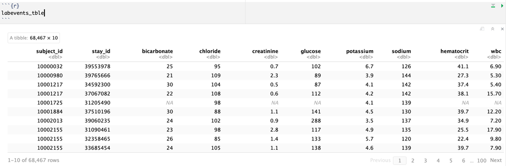

Hint: Use the Parquet format you generated in Homework 2. For reproducibility, make `labevents_pq` folder available at the current working directory `hw3`, for example, by a symbolic link.

**Answer:** The `labevents.parquet` folder is already available at current directory

```r
item_ids_labs <- c(50912, 50971, 50983, 50902, 50882, 51221, 51301, 50931)
d_labitem <- read_csv("~/mimic/hosp/d_labitems.csv.gz") %>%
  filter(itemid %in% item_ids_labs) %>%
  collect()
```

```r
labevents_measure <- arrow::open_dataset("labevents.parquet") %>%
  select(subject_id, storetime, valuenum, itemid) %>%
  filter(itemid %in% d_labitem$itemid) %>%
  filter(subject_id %in% icustays_tble$subject_id) %>%
  collect()
```

```r
labevents_measure <- labevents_measure %>%
  left_join(select(icustays_tble, subject_id, stay_id, intime),
            by = "subject_id") %>%
  filter(storetime <= intime) %>%
  group_by(subject_id, stay_id, itemid) %>%
  arrange(storetime, .by_group = TRUE) %>%
  slice_tail(n = 1) %>%
  select(-storetime, -intime)
```

```r
labevents_final <- labevents_measure %>%
  pivot_wider(names_from = itemid, values_from = valuenum) %>%
  rename_at(
    vars(as.character(d_labitem$itemid)),
    ~str_to_lower(d_labitem$label)
  ) %>%
  print(width = Inf)
```

```
# A tibble: 68,468 × 10
# Groups:   subject_id, stay_id [68,468]
   subject_id  stay_id bicarbonate chloride creatinine glucose potassium sodium
        <dbl>    <dbl>       <dbl>    <dbl>      <dbl>   <dbl>     <dbl>  <dbl>
 1   10000032 39553978          25       95        0.7     102       6.7    126
 2   10000980 39765666          21      109        2.3      89       3.9    144
 3   10001217 34592300          30      104        0.5      87       4.1    142
 4   10001217 37067082          22      108        0.6     112       4.2    142
 5   10001725 31205490          NA       98       NA        NA       4.1    139
 6   10001884 37510196          30       88        1.1     141       4.5    130
 7   10002013 39060235          24      102        0.9     288       3.5    137
 8   10002155 31090461          23       98        2.8     117       4.9    135
 9   10002155 32358465          26       85        1.4     133       5.7    120
10   10002155 33685454          24      105        1.1     138       4.6    139
   hematocrit `white blood cells`
        <dbl>               <dbl>
 1       41.1                 6.9
 2       27.3                 5.3
 3       37.4                 5.4
 4       38.1                15.7
 5       NA                  NA
 6       39.7                12.2
 7       34.9                 7.2
 8       25.5                17.9
 9       22.4                 9.8
10       39.7                 7.9
# ℹ 68,458 more rows
```

## Q6. Vitals from charted events

`chartevents.csv.gz` (https://mimic.mit.edu/docs/iv/modules/icu/chartevents/) contains all the charted data available for a patient. During their ICU stay, the primary repository of a patient’s information is their electronic chart. The `itemid` variable indicates a single measurement type in the database. The `value` variable is the value measured for `itemid`. The first 10 lines of `chartevents.csv.gz` are

```bash
zcat < ~/mimic/icu/chartevents.csv.gz | head
```

```
subject_id,hadm_id,stay_id,caregiver_id,charttime,storetime,itemid,value,valuenum,valueuom,warning
10000032,29079034,39553978,47007,2180-07-23 21:01:00,2180-07-23 22:15:00,220179,82,82,mmHg,0
10000032,29079034,39553978,47007,2180-07-23 21:01:00,2180-07-23 22:15:00,220180,59,59,mmHg,0
10000032,29079034,39553978,47007,2180-07-23 21:01:00,2180-07-23 22:15:00,220181,63,63,mmHg,0
10000032,29079034,39553978,47007,2180-07-23 22:00:00,2180-07-23 22:15:00,220045,94,94,bpm,0
10000032,29079034,39553978,47007,2180-07-23 22:00:00,2180-07-23 22:15:00,220179,85,85,mmHg,0
10000032,29079034,39553978,47007,2180-07-23 22:00:00,2180-07-23 22:15:00,220180,55,55,mmHg,0
10000032,29079034,39553978,47007,2180-07-23 22:00:00,2180-07-23 22:15:00,220181,62,62,mmHg,0
10000032,29079034,39553978,47007,2180-07-23 22:00:00,2180-07-23 22:15:00,220210,20,20,insp/min,0
10000032,29079034,39553978,47007,2180-07-23 22:00:00,2180-07-23 22:15:00,220277,95,95,%,0
```

`d_items.csv.gz` (https://mimic.mit.edu/docs/iv/modules/icu/d_items/) is the dictionary for the `itemid` in `chartevents.csv.gz`.

```bash
zcat < ~/mimic/icu/d_items.csv.gz | head
```

```
itemid,label,abbreviation,linksto,category,unitname,param_type,lownormalvalue,highnormalvalue
220001,Problem List,Problem List,chartevents,General,,Text,,
220003,ICU Admission date,ICU Admission date,datetimeevents,ADT,,Date and time,,
220045,Heart Rate,HR,chartevents,Routine Vital Signs,bpm,Numeric,,
220046,Heart rate Alarm - High,HR Alarm - High,chartevents,Alarms,bpm,Numeric,,
220047,Heart Rate Alarm - Low,HR Alarm - Low,chartevents,Alarms,bpm,Numeric,,
220048,Heart Rhythm,Heart Rhythm,chartevents,Routine Vital Signs,,Text,,
220050,Arterial Blood Pressure systolic,ABPs,chartevents,Routine Vital Signs,mmHg,Numeric,90,140
220051,Arterial Blood Pressure diastolic,ABPd,chartevents,Routine Vital Signs,mmHg,Numeric,60,90
220052,Arterial Blood Pressure mean,ABPm,chartevents,Routine Vital Signs,mmHg,Numeric,,
```

We are interested in the vitals for ICU patients: heart rate (220045), systolic non-invasive blood pressure (220179), diastolic non-invasive blood pressure (220180), body temperature in Fahrenheit (223761), and respiratory rate (220210). Retrieve a subset of `chartevents.csv.gz` only containing these items for the patients in `icustays_tble`. Further restrict to the first vital measurement within the ICU stay. The final `chartevents_tble` should have one row per ICU stay and columns for each vital measurement.

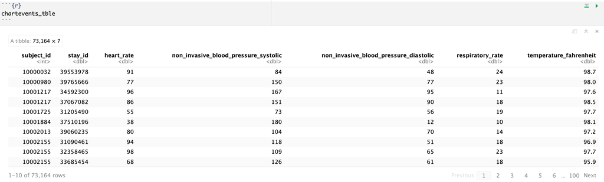

```r
item_ids_vital <- c(220045, 220179, 220180, 223761, 220210)
d_vitalitem <- read_csv("~/mimic/icu/d_items.csv.gz") %>%
  filter(itemid %in% item_ids_vital) %>%
  collect()
```

```r
chartevents_vital <- open_dataset("chartevents.csv", format = "csv") %>%
  select(subject_id, charttime, value, itemid) %>%
  filter(itemid %in% d_vitalitem$itemid) %>%
  filter(subject_id %in% icustays_tble$subject_id) %>%
  collect()
```

```r
chartevents_vital <- chartevents_vital %>%
  left_join(select(icustays_tble, subject_id, stay_id, intime, outtime),
            by = "subject_id")%>%
  filter(charttime >= intime & charttime <= outtime) %>%
  group_by(subject_id, stay_id, itemid) %>%
  arrange(charttime, .by_group = TRUE) %>%
  slice_head(n = 1)
```

```r
chartevents_final <- chartevents_vital %>%
  select(-charttime, -intime, -outtime) %>%
  pivot_wider(names_from = itemid, values_from = value) %>%
  rename_at(
  vars(as.character(d_vitalitem$itemid)),
  ~str_to_lower(d_vitalitem$label)
  ) %>%
  print(width = Inf)
```

```
# A tibble: 73,164 × 7
# Groups:   subject_id, stay_id [73,164]
   subject_id  stay_id `heart rate` `non invasive blood pressure systolic`
        <dbl>    <dbl> <chr>        <chr>
 1   10000032 39553978 91           84
 2   10000980 39765666 77           150
 3   10001217 34592300 96           167
 4   10001217 37067082 86           151
 5   10001725 31205490 55           73
 6   10001884 37510196 38           180
 7   10002013 39060235 80           104
 8   10002155 31090461 94           118
 9   10002155 32358465 98           109
10   10002155 33685454 68           126
   `non invasive blood pressure diastolic` `respiratory rate`
```

[output cut: 24 more lines]

## Q7. Putting things together

Let us create a tibble `mimic_icu_cohort` for all ICU stays, where rows are all ICU stays of adults (age at `intime` >= 18) and columns contain at least following variables

- all variables in `icustays_tble`
- all variables in `admissions_tble`
- all variables in `patients_tble`
- the last lab measurements before the ICU stay in `labevents_tble`
- the first vital measurements during the ICU stay in `chartevents_tble`

The final `mimic_icu_cohort` should have one row per ICU stay and columns for each variable.

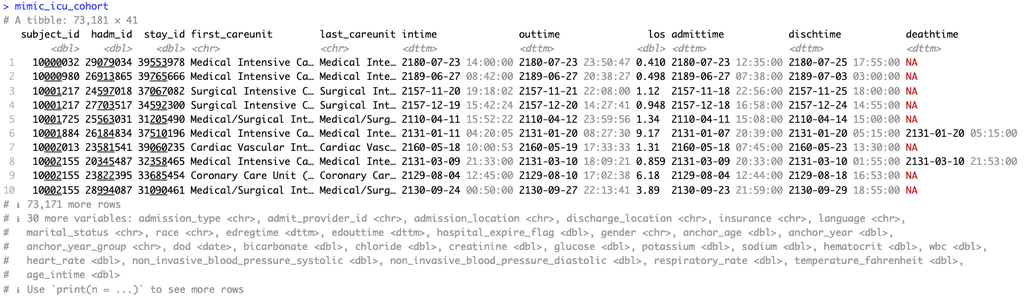

```r
mimic_icu_cohort <- icustays_tble %>%
  left_join(patients_tble, by = c("subject_id")) %>%
  mutate(age_at_intime =  year(intime) + anchor_age - anchor_year) %>%
  filter(age_at_intime >= 18) %>%
  left_join(admissions_tble, by = c("subject_id", "hadm_id")) %>%
  left_join(labevents_final, by = c("subject_id", "stay_id")) %>%
  left_join(chartevents_final, by = c("subject_id", "stay_id")) %>%
  print(width = Inf)
```

```
# A tibble: 73,181 × 44
   subject_id  hadm_id  stay_id first_careunit
        <dbl>    <dbl>    <dbl> <chr>
 1   10000032 29079034 39553978 Medical Intensive Care Unit (MICU)
 2   10000980 26913865 39765666 Medical Intensive Care Unit (MICU)
 3   10001217 24597018 37067082 Surgical Intensive Care Unit (SICU)
 4   10001217 27703517 34592300 Surgical Intensive Care Unit (SICU)
 5   10001725 25563031 31205490 Medical/Surgical Intensive Care Unit (MICU/SICU)
 6   10001884 26184834 37510196 Medical Intensive Care Unit (MICU)
 7   10002013 23581541 39060235 Cardiac Vascular Intensive Care Unit (CVICU)
 8   10002155 20345487 32358465 Medical Intensive Care Unit (MICU)
 9   10002155 23822395 33685454 Coronary Care Unit (CCU)
10   10002155 28994087 31090461 Medical/Surgical Intensive Care Unit (MICU/SICU)
   last_careunit                                    intime
   <chr>                                            <dttm>
```

[output cut: 131 more lines]

## Q8. Exploratory data analysis (EDA)

Summarize the following information about the ICU stay cohort `mimic_icu_cohort` using appropriate numerics or graphs:

- Length of ICU stay `los` vs demographic variables (race, insurance, marital_status, gender, age at intime)

```r
mimic_icu_cohort <- mimic_icu_cohort %>%
  mutate(los_rounded = round(los))
```

[figure not shown]

```r
#race
ggplot(mimic_icu_cohort, aes(x = los, y = race)) +
  geom_point() +
  theme_minimal() +
  labs(x = "Race", y = "Length of ICU Stay")
```

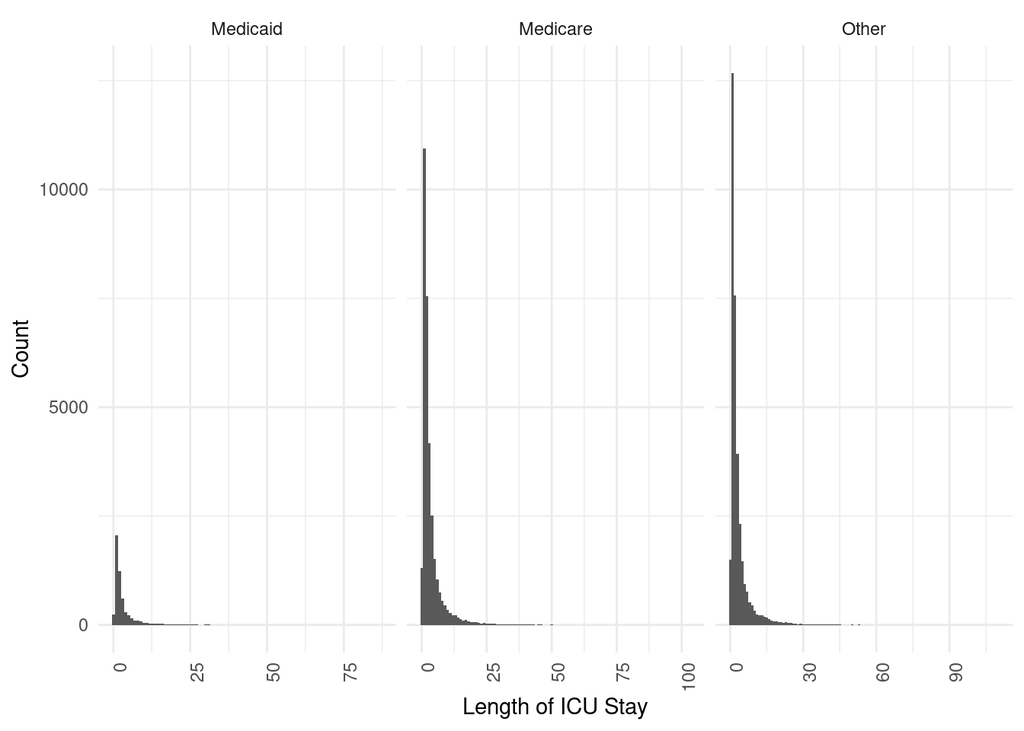

```r
#insurance
ggplot(mimic_icu_cohort, aes(x = los)) +
  geom_histogram(binwidth = 1) +
  facet_wrap(~ insurance, scales = "free_x") +
  theme_minimal() +
  labs(x = "Length of ICU Stay", y = "Count") +
  theme(axis.text.x = element_text(angle = 90, hjust = 1))
```

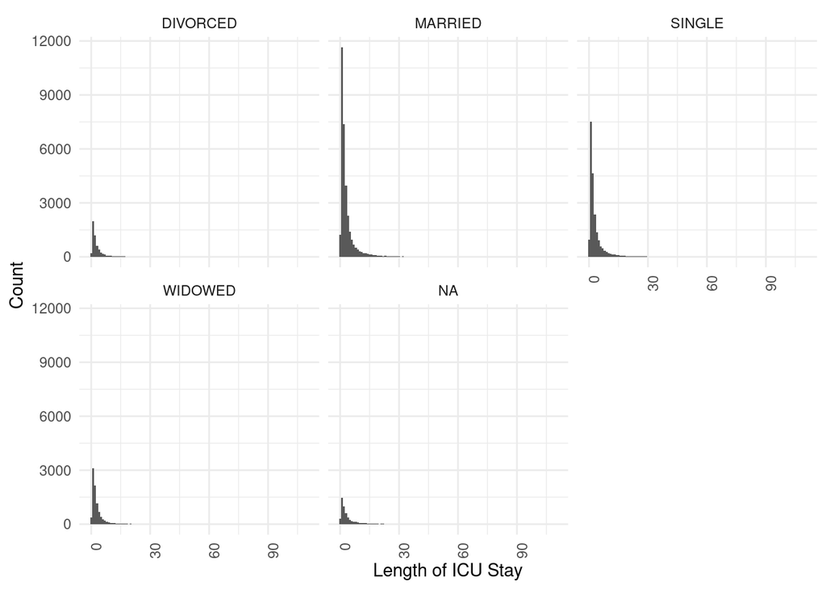

```r
#marital_status
ggplot(mimic_icu_cohort, aes(x = los)) +
  geom_histogram(binwidth = 1) +
  facet_wrap(~ marital_status, scales = "fixed") +
  theme_minimal() +
  labs(x = "Length of ICU Stay", y = "Count") +
  theme(axis.text.x = element_text(angle = 90, hjust = 1))
```

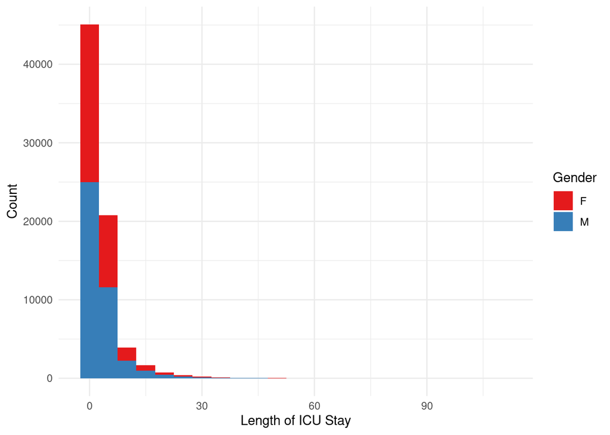

```r
#gender
ggplot(mimic_icu_cohort, aes(x = los, fill = gender)) +
  geom_histogram(binwidth = 5) +
  theme_minimal() +
  labs(x = "Length of ICU Stay", y = "Count", fill = "Gender") +
  scale_fill_brewer(palette = "Set1")
```

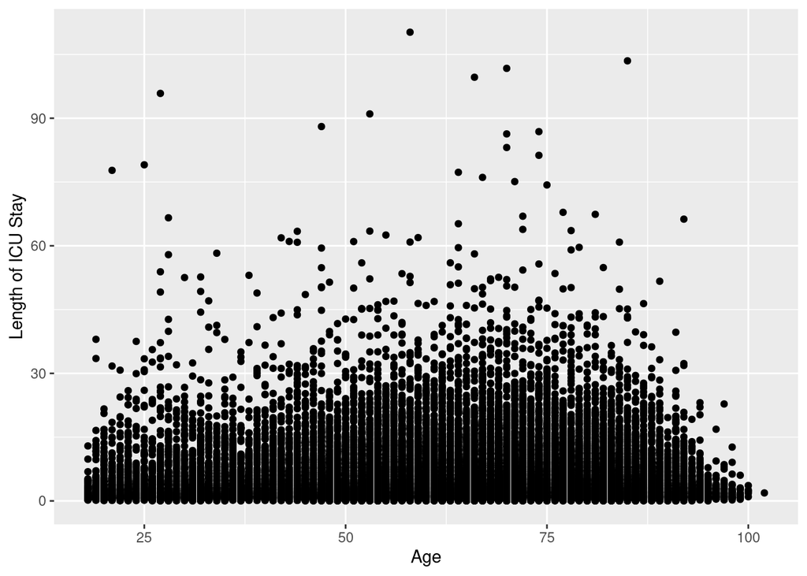

```r
#age at in time
ggplot(mimic_icu_cohort, aes(x = age_at_intime, y = los)) +
  geom_point() +
  labs(x = "Age", y = "Length of ICU Stay")
```

- Length of ICU stay `los` vs the last available lab measurements before ICU stay

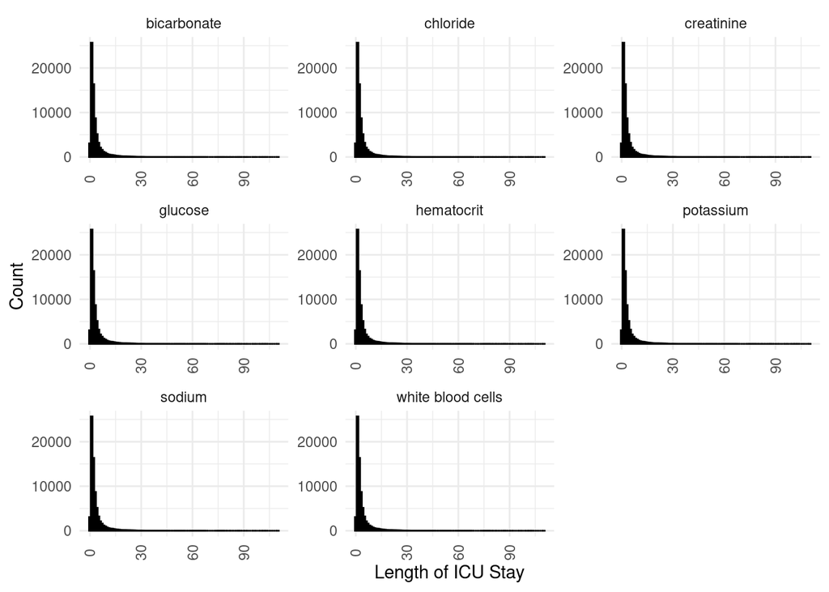

```r
long_data_lab <- mimic_icu_cohort %>%
  pivot_longer(cols = 32:39, names_to = "variable", values_to = "value")

ggplot(long_data_lab, aes(x = los)) +
  geom_histogram(binwidth = 1, color = "black") +
  facet_wrap(~ variable, scales = "free") +
  theme_minimal() +
  labs(x = "Length of ICU Stay", y = "Count") +
  theme(axis.text.x = element_text(angle = 90, vjust = 0.5))
```

- Length of ICU stay `los` vs the first vital measurements within the ICU stay

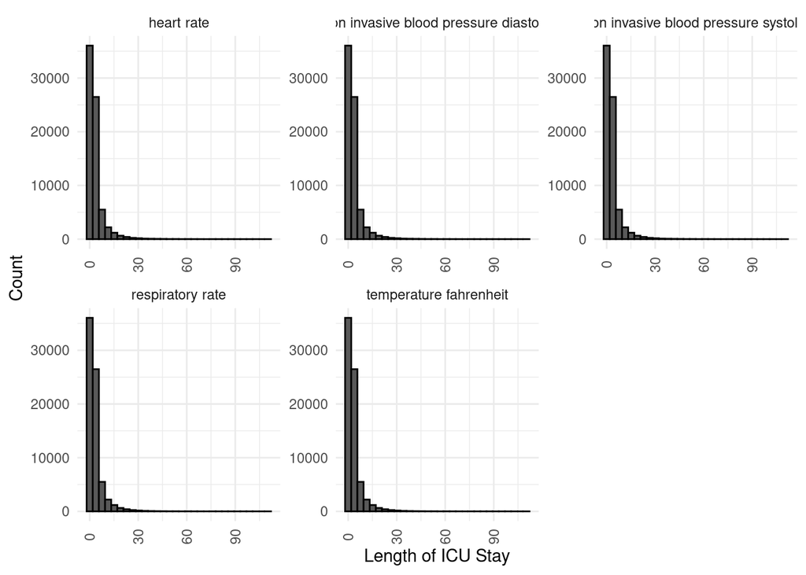

```r
mimic_icu_cohort <- mimic_icu_cohort %>%
  mutate(across(.cols = 40:44, .fns = as.numeric))

long_data_vital <- mimic_icu_cohort %>%
  pivot_longer(cols = 40:44, names_to = "variable",
               values_to = "value")

ggplot(long_data_vital, aes(x = los)) +
  geom_histogram(color = "black") +
  facet_wrap(~ variable, scales = "free") +
  theme_minimal() +
  labs(x = "Length of ICU Stay", y = "Count") +
  theme(axis.text.x = element_text(angle = 90, vjust = 0.5))
```

- Length of ICU stay `los` vs first ICU unit

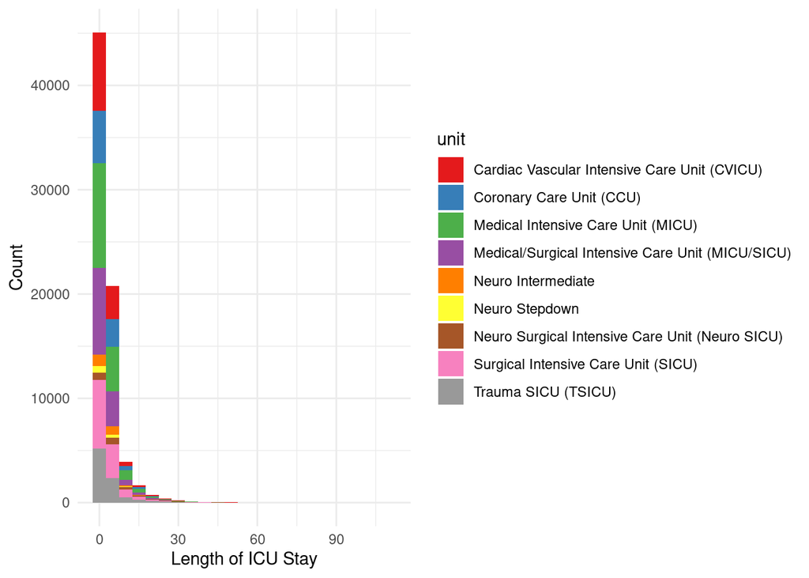

```r
ggplot(mimic_icu_cohort, aes(x = los, fill = first_careunit)) +
  geom_histogram(binwidth = 5) +
  theme_minimal() +
  labs(x = "Length of ICU Stay", y = "Count", fill = "unit") +
  scale_fill_brewer(palette = "Set1")
```